# Hypothesis testing in R

```r
require("BSDA")
library("BSDA")
```

## Power function: one-sided test

We test $H_0: \mu = 0$ vs $H_1: \mu >0$ The graphs of the power functions are give for sample sizes  
- $n$ in red  
- $2n$ in blue  
- $4n$ in green

```r
x <- seq(-.5,1.5,by= .01)
n <- 10
plot(x, 1 - pnorm (qnorm(.9) - x*sqrt(n)), type = "l", col = "red",
     main = "Power function beta(mu) for one-sided test", xlab = "mu_0 = 0", ylab = "beta(mu)", lwd=2)
lines(x, 1 - pnorm (qnorm(.9) - x*sqrt(2*n)), type = "l", col = "blue")
```

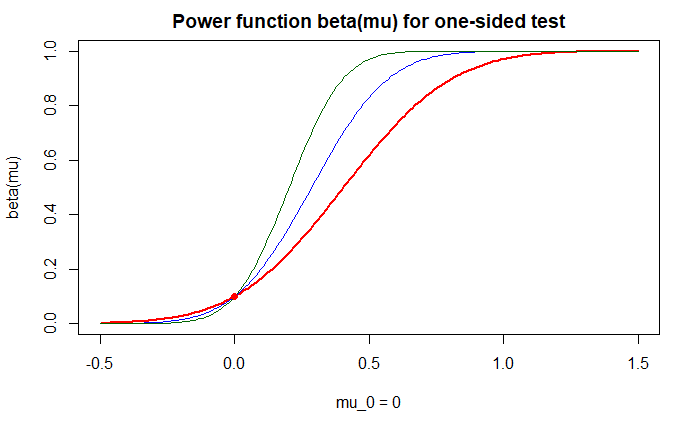

```r
lines(x, 1 - pnorm (qnorm(.9) - x*sqrt(4*n)), type = "l", col = "darkgreen")
points(0,0.1, col= "red", type = "b", pch = 19)
```

### Conclusion:

- the power of the one-sided test with $\mu_1 = 0.5$ is not large enough for the sample size $n=10$;
- this power drastically increases once $n$ has increased to $20$ (blue) and $40$ (green)

## Power function: two-sided test

- two-sided in red
- one-sided in blue

```r
x <- seq(-1,1,by= .01)
n <- 10
plot(x, 1 - pnorm (qnorm(.9) - abs(x)*sqrt(n)), type = "l", col = "red",
     main = "Power function beta(mu) for two-sided test", xlab = "mu_0 = 0", ylab = "beta(mu)", ylim=c(0,1))
points(0,0.1, col= "red", type = "b")
```

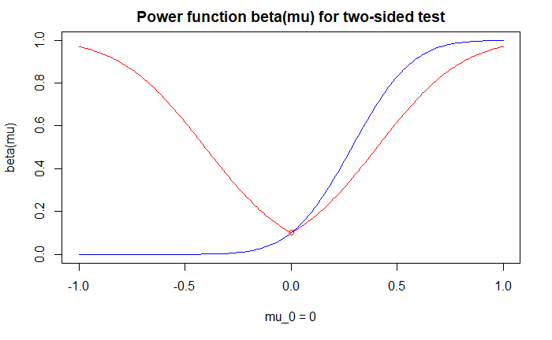

```r
lines(x, 1 - pnorm (qnorm(.9) - x*sqrt(2*n)), type = "l", col = "blue")
```

### Conclusion:

- the two-sided test cannot be uniformly most powerful for all alternative $\mu$;
- the one-sided test has the power function that is the largest possible one for $\mu > \mu_0$

```r
z <- rnorm(1000, mean = c(-2,2), sd = c(1,2))
# z.test requires the BSDA package
z.test(z[z<0], z[z>0], alternative = "g", sigma.x = 1, sigma.y = 2)
```

```
    Two-sample z-Test

data:  z[z < 0] and z[z > 0]
z = -42.193, p-value = 1
alternative hypothesis: true difference in means is greater than 0
95 percent confidence interval:
 -4.665696        NA
sample estimates:
mean of x mean of y
-1.882351  2.608280
```

### Try one-sided alternatives ("t" = "two-sided" is the default):

- "g" = "greater" (the population mean for ${\mathbf{x}}$ is greater than that of ${\mathbf{y}}$)
- "l" = "less" (the population mean ${\mathbf{x}}$ is smaller that that of $\overline{\mathbf{y}}$)
- see how the p-value changes from 1 to 0

## Kolmogorov goodness-of-fit test

### We generate the data from the exponential distribution of rate $\lambda = 0.5$ and test consistency with distribution $\mathcal{E}(\lambda/2)$

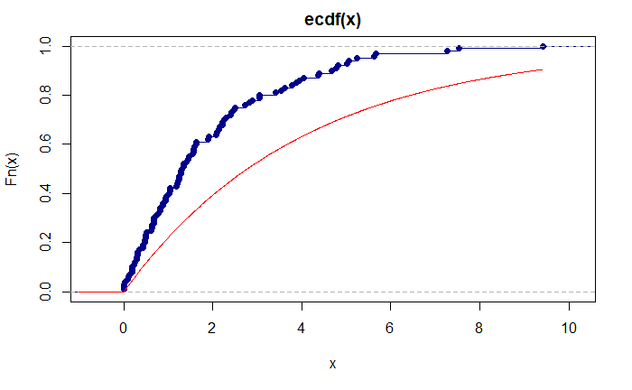

```r
n <- 100
lambda <- .5
x <- rexp(n,rate = lambda)
pts <- seq(-1,max(x),by=0.01)
plot(ecdf(x),col="darkblue")
lines(pts,pexp(pts,rate = lambda/2),col="red")
```

```r
max(abs(pexp(pts, rate = lambda/2)-ecdf(x)(pts)))
```

```
[1] 0.2839249
```

## Kolmogorov-Smirnov goodness-of-fit test

```r
ks.test(x, "pexp",lambda/2, alternative = "l")  # try alternative = "g"", "t"
```

```
    One-sample Kolmogorov-Smirnov test

data:  x
D^- = 0.00058261, p-value = 0.9999
alternative hypothesis: the CDF of x lies below the null hypothesis
```

## Kolmogorov-Smirnov test: two samples

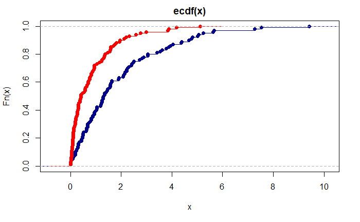

```r
y <- rexp(n, rate = 1)
plot(ecdf(x),col = "darkblue")
lines(ecdf(y), col = "red")
```

## Kolmogorov-Smirnov test: two samples

```r
ks.test(x,y,alternative = "l")
```

```
    Two-sample Kolmogorov-Smirnov test

data:  x and y
D^- = 0.34, p-value = 9.54e-06
alternative hypothesis: the CDF of x lies below that of y
```

## Pearson chi-squared test

### The chi-squared test on multinomial distribution: are the numbers of rolls with points $j$ consistent with prescribed probabilities?

```r
rolls <- c(10,5,10,15,12,20)
chisq.test(rolls, p = c(.2,.1,.1,.2,.2,.2))
```

```
    Chi-squared test for given probabilities

data:  rolls
X-squared = 5.7083, df = 5, p-value = 0.3356
```

## Mendel test

### In this test, the p-value is so high that many believe that his assistent has frauded the results ;)

```r
peas <- c(315,108,102,31)
prob <- c(9/16,3/16,3/16,1/16)
chisq.test(peas, p = prob)
```

```
    Chi-squared test for given probabilities

data:  peas
X-squared = 0.60432, df = 3, p-value = 0.8954
```

## Aspirin vs Placebo

### We tested homogeneity of the distributions of heart problems among the patients in the test and control group, to detect the effect

```r
heart_attack <- matrix(c(104,189,10933,10845),nrow = 2)
chisq.test(heart_attack)
```

```
    Pearson's Chi-squared test with Yates' continuity correction

data:  heart_attack
X-squared = 24.429, df = 1, p-value = 7.71e-07
```